# Lab 05 - La Quinta is Spanish for next to Denny’s, Pt. 2

Sebastian Kaltenbach

2021-10-17

### Load packages and data

```r
library(tidyverse)
library(dsbox)
library(stringr)
```

```r
dn <- dennys
lq <- laquinta
```

Load U.S. state information in local variable

```r
states <- read_csv("data/states.csv")
```

### Exercise 1

Filter the Denny’s dataframe for Alaska (AK) and save the result as dn_ak. How many Denny’s locations are there in Alaska?

```r
dn_ak <- dennys %>%
  filter(state == "AK")
nrow(dn_ak)
```

```
[1] 3
```

### Exercise 2

Filter the La Quinta dataframe for Alaska (AK) and save the result as lq_ak. How many La Quinta locations are there in Alaska?

```r
lq_ak <- laquinta %>%
  filter(state == "AK")
nrow(lq_ak)
```

```
[1] 2
```

### Exercise 3

How many pairings are there between all Denny’s and all La Quinta locations in Alaska, i.e. how many distances do we need to calculate between the locations of these establishments in Alaska?

```r
nrow(dn_ak) * nrow(lq_ak)
```

```
[1] 6
```

Combine Denny’s and La Quinta dataset for distance calculation.

```r
dn_lq_ak <- full_join(dn_ak, lq_ak, by = "state")
dn_lq_ak
```

| address.x | city.x | state | zip.x | longitude.x | latitude.x | address.y | city.y | zip.y | longitude.y | latitude.y |
| --- | --- | --- | --- | --- | --- | --- | --- | --- | --- | --- |
| 2900 Denali | Anchorage | AK | 99503 | -149.8767 | 61.1953 | 3501 Minnesota Dr. | \nAnchorage | 99503 | -149.9119 | 61.18843 |
| 2900 Denali | Anchorage | AK | 99503 | -149.8767 | 61.1953 | 4920 Dale Rd | \nFairbanks | 99709 | -147.8660 | 64.82426 |
| 3850 Debarr Road | Anchorage | AK | 99508 | -149.8090 | 61.2097 | 3501 Minnesota Dr. | \nAnchorage | 99503 | -149.9119 | 61.18843 |
| 3850 Debarr Road | Anchorage | AK | 99508 | -149.8090 | 61.2097 | 4920 Dale Rd | \nFairbanks | 99709 | -147.8660 | 64.82426 |
| 1929 Airport Way | Fairbanks | AK | 99701 | -147.7600 | 64.8366 | 3501 Minnesota Dr. | \nAnchorage | 99503 | -149.9119 | 61.18843 |
| 1929 Airport Way | Fairbanks | AK | 99701 | -147.7600 | 64.8366 | 4920 Dale Rd | \nFairbanks | 99709 | -147.8660 | 64.82426 |

### Exercise 4

How many observations are in the joined dn_lq_ak data frame? What are the names of the variables in this data frame.

```r
glimpse(dn_lq_ak)
```

```
Rows: 6
Columns: 11
$ address.x   <chr> "2900 Denali", "2900 Denali", "3850 Debarr Road", "3850 Debarr Road", "1929 Airport Way", "1929 Airport Way"
$ city.x      <chr> "Anchorage", "Anchorage", "Anchorage", "Anchorage", "Fairbanks", "Fairbanks"
$ state       <chr> "AK", "AK", "AK", "AK", "AK", "AK"
$ zip.x       <chr> "99503", "99503", "99508", "99508", "99701", "99701"
$ longitude.x <dbl> -149.8767, -149.8767, -149.8090, -149.8090, -147.7600, -147.7600
$ latitude.x  <dbl> 61.1953, 61.1953, 61.2097, 61.2097, 64.8366, 64.8366
$ address.y   <chr> "3501 Minnesota Dr.", "4920 Dale Rd", "3501 Minnesota Dr.", "4920 Dale Rd", "3501 Minnesota Dr.", "4920 Dale Rd"
$ city.y      <chr> "\nAnchorage", "\nFairbanks", "\nAnchorage", "\nFairbanks", "\nAnchorage", "\nFairbanks"
$ zip.y       <chr> "99503", "99709", "99503", "99709", "99503", "99709"
$ longitude.y <dbl> -149.9119, -147.8660, -149.9119, -147.8660, -149.9119, -147.8660
$ latitude.y  <dbl> 61.18843, 64.82426, 61.18843, 64.82426, 61.18843, 64.82426
```

### Exercise 5

What function from the tidyverse do we use the add a new variable to a data frame while keeping the existing variables?

The ‘mutate’ function.

The following function is provided by Data Science in a box and is calculating the distance between two locations (lat, long).

```r
haversine <- function(long1, lat1, long2, lat2, round = 3) {
  # convert to radians
  long1 = long1 * pi / 180
  lat1  = lat1  * pi / 180
  long2 = long2 * pi / 180
  lat2  = lat2  * pi / 180

  R = 6371 # Earth mean radius in km

  a = sin((lat2 - lat1)/2)^2 + cos(lat1) * cos(lat2) * sin((long2 - long1)/2)^2
  d = R * 2 * asin(sqrt(a))

  return( round(d,round) ) # distance in km
}
```

### Exercise 6

Calculate the distances between all pairs of Denny’s and La Quinta locations and save this variable as distance. Make sure to save this variable in THE dn_lq_ak data frame so that you can use it later.

```r
dn_lq_ak <- dn_lq_ak %>%
  mutate(distance = haversine(longitude.x, latitude.x, longitude.y, latitude.y))
dn_lq_ak
```

| address.x | city.x | state | zip.x | longitude.x | latitude.x | address.y | city.y | zip.y | longitude.y | latitude.y | distance |
| --- | --- | --- | --- | --- | --- | --- | --- | --- | --- | --- | --- |
| 2900 Denali | Anchorage | AK | 99503 | -149.8767 | 61.1953 | 3501 Minnesota Dr. | \nAnchorage | 99503 | -149.9119 | 61.18843 | 2.035 |
| 2900 Denali | Anchorage | AK | 99503 | -149.8767 | 61.1953 | 4920 Dale Rd | \nFairbanks | 99709 | -147.8660 | 64.82426 | 416.031 |
| 3850 Debarr Road | Anchorage | AK | 99508 | -149.8090 | 61.2097 | 3501 Minnesota Dr. | \nAnchorage | 99503 | -149.9119 | 61.18843 | 5.998 |
| 3850 Debarr Road | Anchorage | AK | 99508 | -149.8090 | 61.2097 | 4920 Dale Rd | \nFairbanks | 99709 | -147.8660 | 64.82426 | 413.653 |
| 1929 Airport Way | Fairbanks | AK | 99701 | -147.7600 | 64.8366 | 3501 Minnesota Dr. | \nAnchorage | 99503 | -149.9119 | 61.18843 | 419.879 |
| 1929 Airport Way | Fairbanks | AK | 99701 | -147.7600 | 64.8366 | 4920 Dale Rd | \nFairbanks | 99709 | -147.8660 | 64.82426 | 5.197 |

### Exercise 7

Calculate the minimum distance between a Denny’s and La Quinta for each Denny’s location. To do so we group by Denny’s locations and calculate a new variable that stores the information for the minimum distance.

```r
dn_lq_ak_mindist <- dn_lq_ak %>%
  group_by(address.x) %>%
  summarise(closest = min(distance))
dn_lq_ak_mindist
```

| address.x | closest |
| --- | --- |
| 1929 Airport Way | 5.197 |
| 2900 Denali | 2.035 |
| 3850 Debarr Road | 5.998 |

### Exercise 8

Describe the distribution of the distances Denny’s and the nearest La Quinta locations in Alaska. Also include an appripriate visualization and relevant summary statistics.

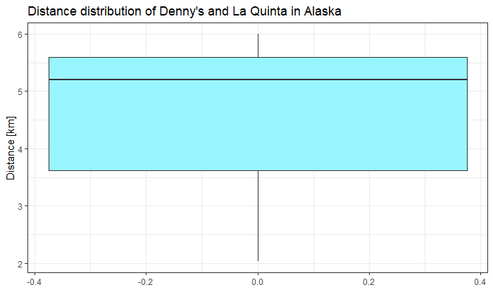

```r
ggplot(data = dn_lq_ak_mindist, aes(y = closest)) +
  geom_boxplot(fill="cadetblue1") +
  theme_bw() +
  labs(title = "Distance distribution of Denny's and La Quinta in Alaska",
       x = "", y = "Distance [km]")
```

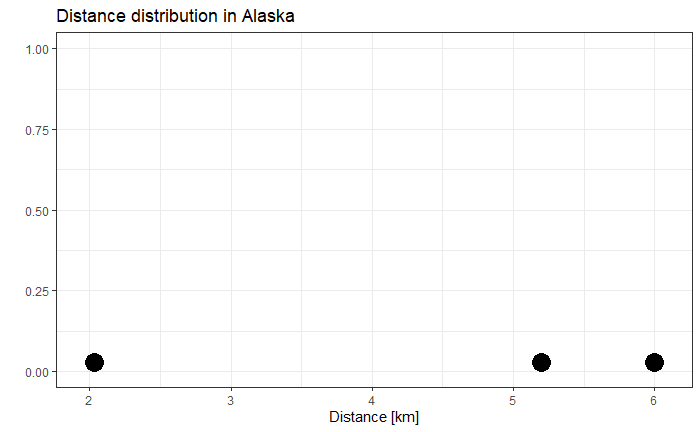

```r
ggplot(data = dn_lq_ak_mindist, aes(x = closest)) +
 geom_dotplot() +
  theme_bw() +
  labs(title = "Distance distribution in Alaska",
       x = "Distance [km]", y = "")
```

### Exercise 9

Repeat the same analysis for North Carolina: (i) filter Denny’s and La Quinta Data Frames for NC, (ii) join these data frames to get a completelist of all possible pairings, (iii) calculate the distances between all possible pairings of Denny’s and La Quinta in NC, (iv) find the minimum distance between each Denny’s and La Quinta location, (v) visualize and describe the distribution of these shortest distances using appropriate summary statistics.

```r
dn_lq_nc <- full_join(dennys %>% filter(state == "NC"), laquinta %>% filter(state == "NC"), by = "state") %>%
  mutate(distance = haversine(longitude.x, latitude.x, longitude.y, latitude.y))
dn_lq_nc
```

| address.x | city.x | state | zip.x | longitude.x | latitude.x | address.y | city.y | zip.y | longitude.y | latitude.y | distance |
| --- | --- | --- | --- | --- | --- | --- | --- | --- | --- | --- | --- |
| 1 Regent Park Boulevard | Asheville | NC | 28806 | -82.5820 | 35.5888 | 165 Hwy 105 Extension | \nBoone | 28607 | -81.66881 | 36.21550 | 107.801 |
| 1 Regent Park Boulevard | Asheville | NC | 28806 | -82.5820 | 35.5888 | 3127 Sloan Dr | \nCharlotte | 28208 | -80.92088 | 35.24087 | 155.423 |
| 1 Regent Park Boulevard | Asheville | NC | 28806 | -82.5820 | 35.5888 | 4900 South Tryon St | \nCharlotte | 28217 | -80.89117 | 35.17895 | 159.913 |
| 1 Regent Park Boulevard | Asheville | NC | 28806 | -82.5820 | 35.5888 | 4414 Durham Chapel Hill Blvd | \nDurham | 27707 | -78.97218 | 35.96460 | 328.301 |
| 1 Regent Park Boulevard | Asheville | NC | 28806 | -82.5820 | 35.5888 | 1910 Westpark Dr | \nDurham | 27713 | -78.89145 | 35.90796 | 334.918 |
| 1 Regent Park Boulevard | Asheville | NC | 28806 | -82.5820 | 35.5888 | 1201 Lanada Rd | \nGreensboro | 27407 | -79.89346 | 36.05371 | 247.847 |
| 1 Regent Park Boulevard | Asheville | NC | 28806 | -82.5820 | 35.5888 | 1607 Fairgrove Church Rd | \nConover | 28613 | -81.26184 | 35.70027 | 119.934 |
| 1 Regent Park Boulevard | Asheville | NC | 28806 | -82.5820 | 35.5888 | 191 Crescent Commons | \nCary | 27518 | -78.78415 | 35.73580 | 343.474 |
| 1 Regent Park Boulevard | Asheville | NC | 28806 | -82.5820 | 35.5888 | 2211 Summit Park Ln | \nRaleigh | 27612 | -78.67605 | 35.83362 | 353.681 |
| 1 Regent Park Boulevard | Asheville | NC | 28806 | -82.5820 | 35.5888 | 1001 Aerial Center Pkwy | \nMorrisville | 27560 | -78.81659 | 35.85856 | 341.213 |

[output cut: 326 more lines]

```r
dn_lq_nc_mindist <- dn_lq_nc %>%
  group_by(address.x) %>%
  summarise(closest = min(distance))
dn_lq_nc_mindist
```

| address.x | closest |
| --- | --- |
| 1 Regent Park Boulevard | 107.801 |
| 101 Wintergreen Dr | 120.422 |
| 103 Sedgehill Dr | 26.711 |
| 1043 Jimmie Kerr Road | 36.130 |
| 1201 S College Road | 187.935 |
| 1209 Burkemount Avenue | 39.115 |
| 1493 Us Hwy 74-A Bypass | 70.144 |
| 1524 Dabney Dr | 59.544 |
| 1550 Four Seasons | 114.947 |
| 1800 Princeton-Kenly Road | 55.909 |

[output cut: 18 more lines]

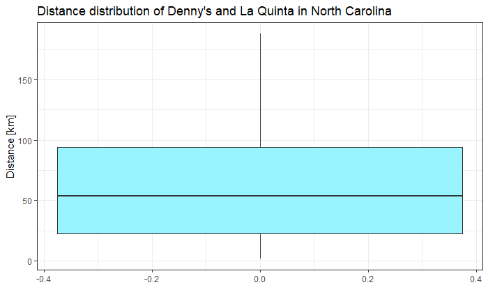

```r
ggplot(data = dn_lq_nc_mindist, aes(y = closest)) +
  geom_boxplot() +
  geom_boxplot(fill="cadetblue1") +
  theme_bw() +
  labs(title = "Distance distribution of Denny's and La Quinta in North Carolina",
       x = "", y = "Distance [km]")
```

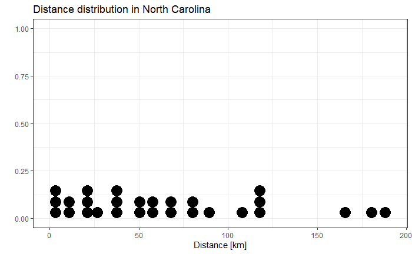

```r
ggplot(data = dn_lq_nc_mindist, aes(x = closest)) +
 geom_dotplot() +
  theme_bw() +
  labs(title = "Distance distribution in North Carolina",
       x = "Distance [km]", y = "")
```

### Exercise 10

Repeat the same analysis for Texas.

```r
dn_lq_tx <- full_join(dennys %>% filter(state == "TX"), laquinta %>% filter(state == "TX"), by = "state") %>%
  mutate(distance = haversine(longitude.x, latitude.x, longitude.y, latitude.y))
dn_lq_tx
```

| address.x | city.x | state | zip.x | longitude.x | latitude.x | address.y | city.y | zip.y | longitude.y | latitude.y | distance |
| --- | --- | --- | --- | --- | --- | --- | --- | --- | --- | --- | --- |
| 120 East I-20 | Abilene | TX | 79601 | -99.6435 | 32.4394 | 3018 CatClaw Dr | \nAbilene | 79606 | -99.77877 | 32.41349 | 13.018 |
| 120 East I-20 | Abilene | TX | 79601 | -99.6435 | 32.4394 | 3501 West Lake Rd | \nAbilene | 79601 | -99.72269 | 32.49136 | 9.411 |
| 120 East I-20 | Abilene | TX | 79601 | -99.6435 | 32.4394 | 14925 Landmark Blvd | \nAddison | 75254 | -96.82874 | 32.95164 | 269.474 |
| 120 East I-20 | Abilene | TX | 79601 | -99.6435 | 32.4394 | 909 East Frontage Rd | \nAlamo | 78516 | -98.11925 | 26.18997 | 710.415 |
| 120 East I-20 | Abilene | TX | 79601 | -99.6435 | 32.4394 | 2400 East Main St | \nAlice | 78332 | -98.04351 | 27.76425 | 542.135 |
| 120 East I-20 | Abilene | TX | 79601 | -99.6435 | 32.4394 | 1220 North Central Expressway | \nAllen | 75013 | -96.66739 | 33.11674 | 288.237 |
| 120 East I-20 | Abilene | TX | 79601 | -99.6435 | 32.4394 | 1165 Hwy 67W | \nAlvarado | 76009 | -97.22377 | 32.41490 | 227.120 |
| 120 East I-20 | Abilene | TX | 79601 | -99.6435 | 32.4394 | 880 South Loop 35 | \nAlvin | 77511 | -95.23011 | 29.41755 | 538.526 |
| 120 East I-20 | Abilene | TX | 79601 | -99.6435 | 32.4394 | 1708 Interstate 40 East | \nAmarillo | 79103 | -101.81877 | 35.19200 | 366.125 |
| 120 East I-20 | Abilene | TX | 79601 | -99.6435 | 32.4394 | 9305 East Interstate 40 | \nAmarillo | 79118 | -101.73149 | 35.19372 | 361.925 |

[output cut: 990 more lines]

```r
dn_lq_tx_mindist <- dn_lq_tx %>%
  group_by(address.x) %>%
  summarise(closest = min(distance))
dn_lq_tx_mindist
```

| address.x | closest |
| --- | --- |
| 100 Cottonwood | 33.619 |
| 100 E Pinehurst | 1.391 |
| 100 Us Highway 79 S | 33.878 |
| 101 N Fm 707 | 10.272 |
| 1011 Beltway Parkway | 14.026 |
| 1015 Spur 350 West | 1.735 |
| 1015 West Main St | 1.097 |
| 10367 Highway 59 | 37.599 |
| 10433 N Central Expwy | 0.618 |
| 105 W 42nd St | 6.881 |

[output cut: 190 more lines]

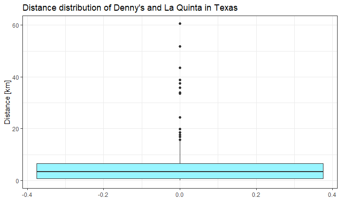

```r
ggplot(data = dn_lq_tx_mindist, aes(y = closest)) +
  geom_boxplot() +
  geom_boxplot(fill="cadetblue1") +
  theme_bw() +
  labs(title = "Distance distribution of Denny's and La Quinta in Texas",
       x = "", y = "Distance [km]")
```

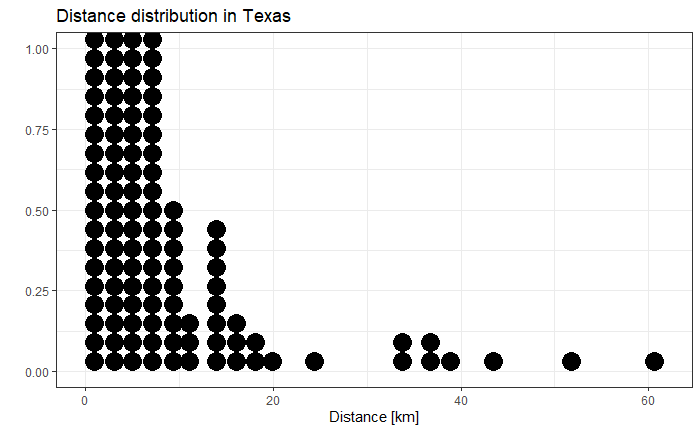

```r
ggplot(data = dn_lq_tx_mindist, aes(x = closest)) +
 geom_dotplot() +
  theme_bw() +
  labs(title = "Distance distribution in Texas",
       x = "Distance [km]", y = "")
```

### Exercise 11

Repeat the same analysis for a state of your choosing, different than the ones we covered so far.

State New York - NY

```r
dn_lq_ny <- full_join(dennys %>% filter(state == "NY"), laquinta %>% filter(state == "NY"), by = "state") %>%
  mutate(distance = haversine(longitude.x, latitude.x, longitude.y, latitude.y))
dn_lq_ny
```

| address.x | city.x | state | zip.x | longitude.x | latitude.x | address.y | city.y | zip.y | longitude.y | latitude.y | distance |
| --- | --- | --- | --- | --- | --- | --- | --- | --- | --- | --- | --- |
| 114 Wolf Road | Albany | NY | 12205 | -73.8078 | 42.7178 | 94 Business Park Dr | \nArmonk | 10504 | -73.70732 | 41.12099 | 177.752 |
| 114 Wolf Road | Albany | NY | 12205 | -73.8078 | 42.7178 | 8200 Park Road | \nBatavia | 14020 | -78.19307 | 43.01731 | 358.897 |
| 114 Wolf Road | Albany | NY | 12205 | -73.8078 | 42.7178 | 581 Harry L. Dr | \nJohnson City | 13790 | -75.97092 | 42.12472 | 189.403 |
| 114 Wolf Road | Albany | NY | 12205 | -73.8078 | 42.7178 | 1229 Atlantic Ave. | \nBrooklyn | 11216 | -73.95026 | 40.67881 | 227.034 |
| 114 Wolf Road | Albany | NY | 12205 | -73.8078 | 42.7178 | 533 3rd Ave | \nBrooklyn | 11215 | -73.99303 | 40.66904 | 228.330 |
| 114 Wolf Road | Albany | NY | 12205 | -73.8078 | 42.7178 | 1412 Pitkin Ave | \nBrooklyn | 11233 | -73.92154 | 40.66831 | 228.088 |
| 114 Wolf Road | Albany | NY | 12205 | -73.8078 | 42.7178 | 6619 Transit Rd | \nWilliamsville | 14221 | -78.69662 | 42.94790 | 399.416 |
| 114 Wolf Road | Albany | NY | 12205 | -73.8078 | 42.7178 | 1749 Route 9 | \nClifton Park | 12065 | -73.77206 | 42.87093 | 17.275 |
| 114 Wolf Road | Albany | NY | 12205 | -73.8078 | 42.7178 | 540 Saw Mill River Rd | \nElmsford | 10523 | -73.81739 | 41.07352 | 182.837 |
| 114 Wolf Road | Albany | NY | 12205 | -73.8078 | 42.7178 | 4317 Rockaway Beach Blvd. | \nFar Rockaway | 11692 | -73.77519 | 40.59355 | 236.222 |

[output cut: 990 more lines]

```r
dn_lq_ny_mindist <- dn_lq_ny %>%
  group_by(address.x) %>%
  summarise(closest = min(distance))
dn_lq_ny_mindist
```

| address.x | closest |
| --- | --- |
| 1 River St | 55.957 |
| 103 Elwood Davis Road | 47.087 |
| 10390 Bennet Road | 74.365 |
| 1078 Glenwood Avenue | 6.400 |
| 114 Wolf Road | 5.400 |
| 1142 Arsenal St | 99.044 |
| 1143 Deer Park Ave | 19.567 |
| 118 Victory Highway | 93.802 |
| 1250 Upper Front St | 7.161 |
| 126 Troy Rd | 15.003 |

[output cut: 46 more lines]

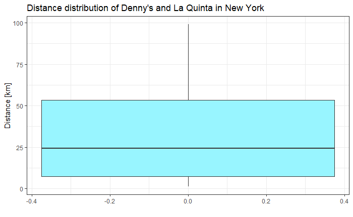

```r
ggplot(data = dn_lq_ny_mindist, aes(y = closest)) +
  geom_boxplot() +
  geom_boxplot(fill="cadetblue1") +
  theme_bw() +
  labs(title = "Distance distribution of Denny's and La Quinta in New York",
       x = "", y = "Distance [km]")
```

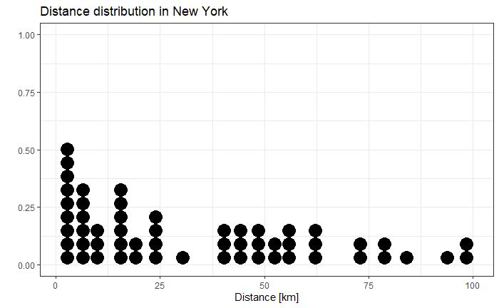

```r
ggplot(data = dn_lq_ny_mindist, aes(x = closest)) +
 geom_dotplot() +
  theme_bw() +
  labs(title = "Distance distribution in New York",
       x = "Distance [km]", y = "")
```

### Exercise 12

Among the states you examined, where is Mitch Hedberg’s joke most likely to hold true? Explain your reasoning.

## Function - Create dataframe by state

1. Get all of lab 5 working, to include creating a function that takes a “state” as input and produces the output dataframe of distinces.
2. Modify (probably already done in class) so that … given a state, if creates a dataframe that for each la quinta, it includes distance to nearest dennys.

```r
analyze_state <- function(this_state) {

  dn_state <- dn %>%
    filter(state == this_state)

  lq_state <- lq %>%
    filter(state == this_state)

  dm_lq_state_mindist <-- full_join(dn_state, lq_state, by = "state") %>%
    mutate(
      distance = haversine(longitude.x, latitude.x, longitude.y, latitude.y, round = 4)
    ) %>%
    group_by(address.x) %>%
    summarise(closest = min(distance))

  return( dm_lq_state_mindist )
}
```

3. Grab the dataset (available in moodle in “week of 28 Sep” ) for the 10000 US restaurants.

```r
FastFoodRestaurants <- read_csv("FastFoodRestaurants.csv")
FastFoodRestaurants <- FastFoodRestaurants %>%
  rename(state = province) %>%
  mutate(name = tolower(name),
         name = str_replace_all(name, fixed(" "), ""),
         name = str_replace_all(name, fixed("'"), ""),
         name = str_replace_all(name, fixed("/"), ""),
         name = str_replace_all(name, fixed("-"), ""))


# fastfood_ny <- FastFoodRestaurants %>%
#   filter(province == "NY")
#
# FastFoodRestaurants <- FastFoodRestaurants %>%
#   mutate(state = province) %>%
#   mutate(name = tolower(name),
#          name = str_replace_all(name, fixed(" "), ""),
#          name = str_replace_all(name, fixed("'"), ""))
#
#
# fastfood_ny <- full_join(dennys %>% filter(state =="NY"), fastfood_ny, by = "state")
#
#
# lq_ff_ny <- full_join(laquinta %>% filter(state == "NY"), fastfood_ny, by = "state") %>%
#   mutate(distance = haversine(longitude.x, latitude.x, longitude.y, latitude.y))
#
#
# #lq_ff <- full_join(laquinta, FastFoodRestaurants, by = "state") %>%
# #  mutate(distance = haversine(longitude.x, latitude.x, longitude.y, latitude.y))
# #lq_ff
#
# lq_ff_ny <- lq_ff_ny %>%
#   group_by(address.x, name.x) %>%
#   summarise(closest = min(distance))
# lq_ff_ny
#
# test <- FastFoodRestaurants %>% filter(name == "mcdonalds", state == "NY")
#
# ggplot(data = lq_ff_ny, aes(x = closest)) +
#  geom_dotplot() +
#   theme_bw() +
#   labs(title = "",
#        x = "Distance [km]", y = "")
```

4. Create a function that takes a “state” as input and produces a dataframe, where there is one observation per “la quinta” and it lists distance to nearest “Restaurant”. WHEN YOU BUILD THIS FUNCTION … ensure it is pulling a sample from the state of interest AND that the sample size is similar to the number of Denny’s in the state. (Hint - use “sample_n” function from dplyr.)

```r
test <- function(this_state, this_restaurant) {

  dn_state <- dn %>%
    filter(state == this_state)

  lq_state <- lq %>%
    filter(state == this_state)

  fastfood_state <- FastFoodRestaurants %>%
    filter(state == this_state) %>%
    filter(name == this_restaurant)

  fastfood_sample <- sample_n(fastfood_state, nrow(dn_state))

  dn_mindist <- full_join(dn_state, lq_state, by = "state") %>%
    mutate(
      distance = haversine(longitude.x, latitude.x, longitude.y, latitude.y, round = 4)
    ) %>%
    group_by(address.x) %>%
    summarise(closest = min(distance)) %>%
    mutate(name = "dennys")

  ff_mindist <- full_join(fastfood_sample, lq_state, by = "state") %>%
    mutate(
      distance = haversine(longitude.x, latitude.x, longitude.y, latitude.y, round = 4)
    ) %>%
    group_by(address.x) %>%
    summarise(closest = min(distance)) %>%
    mutate(name = this_restaurant)



  return (ff_mindist)
}
```

```r
test_df <- test("NY", "mcdonalds")
```